# CH08P44 Student t Test One Sample

crl

January 24, 2018

```r
knitr::opts_chunk$set(echo = TRUE)
```

# QCI Six Sigma Primer

## Student t Test One Sample (page VIII-44)

### Read More

Where the population variance is not known, a Student’s t-test is used to compare means.  
The One Sample Student t Test is used to compare a sample mean to a target value.

[Student t Test Wikipedia](https://en.wikipedia.org/wiki/Student%27s_t-test#One-sample_t-test)

[One Sample Student t Test Wikipedia](https://en.wikipedia.org/wiki/Student%27s_t-test#One-sample_t-test)

The One Sample t-Test compares a sample mean to a known or hypothesized mean. [Example here](https://www.statmethods.net/stats/ttest.html)

[Read more (Berkeley)](https://statistics.berkeley.edu/computing/r-t-tests)

[Presentation](https://docs.google.com/presentation/d/e/2PACX-1vQHzYZ-PB8lu0ViBuok34ltHeuz4tihqMDNHvRccPIa6bDfZXEvzys3aoBWe7quW6wkEU07tRto4-L8/pub?start=false&loop=false&delayms=10000)

# Analysis

## Load Packages

```r
library(tidyverse)
```

## Primer Example 8.15

Prepare the data set

```r
dat_wear <- c(0.0058, 0.0049, 0.0052, 0.0044, 0.0050, 0.0047)
```

### Now we perform the one sample t test

The historical mean = 0.0055 (what we compare the sample mean against)  
alpha = 0.05

The question asks “is the new design ‘better’?” This is the **research hypothesis**.

- By ‘better’ we might assume this means *LESS* wear.
- The new sample mean is *LESS THAN* the historical mean.

The **null hypothesis** would then be the ‘status quo’

- aka ‘no improvement’,
- aka ‘not better (but possibly the same as or worse)’
- aka *EQUAL OR MORE* wear.

H0: new mean >= historical mean  
HA: new mean < historical mean

Plot the sample data

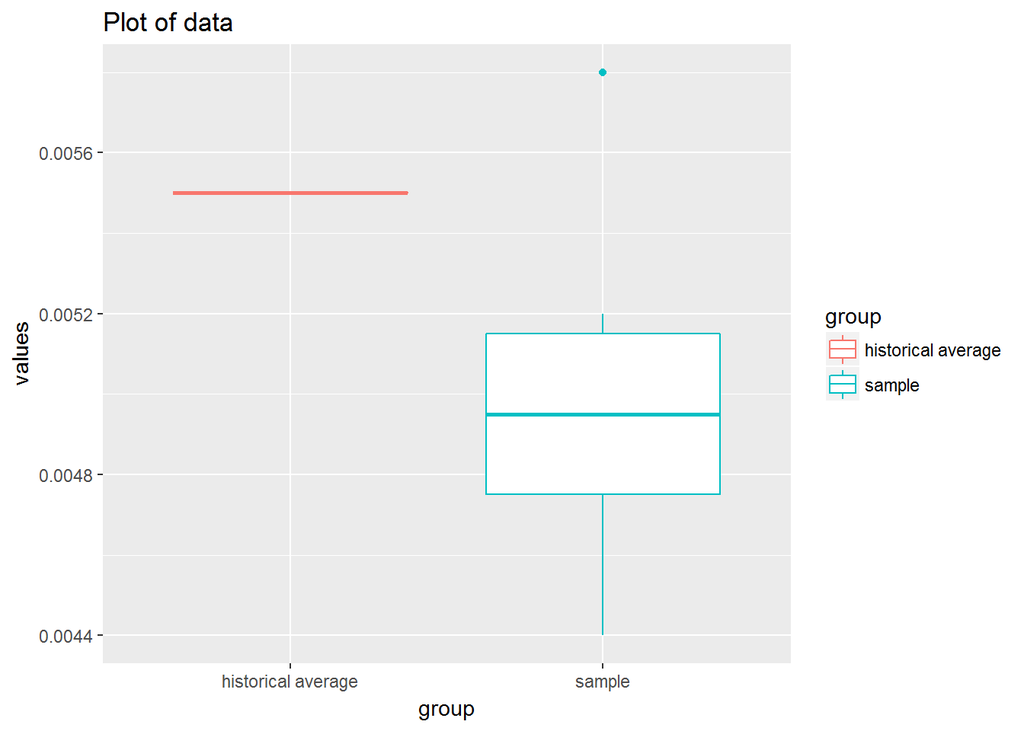

```r
histavg <- 0.0055
df_wear <- data.frame(values = c(dat_wear, histavg),
                      group = c(rep('sample', length(dat_wear)), 'historical average'))

ggplot(df_wear, aes(x = group, y = values, color = group)) +
  geom_boxplot() +
  ggtitle('Plot of data')
```

With a one-sided hypothesis, we put all of alpha into one tail, which affects the critical value of t that defines the rejection region.

The critical value (one-sided) of t with (n-1) degrees of freedom.

```r
hypalpha <- 0.05
degf <- length(dat_wear) - 1
tcrit <- round(qt(p = hypalpha, df = degf), 3)
cat(paste('Critical value of t =', tcrit, 'with degrees of freedom =', degf))
```

```
## Critical value of t = -2.015 with degrees of freedom = 5
```

Look at both the p-value of the t-test and the confidence interval of the sample mean.

```r
tcalc_out <- t.test(dat_wear, mu = histavg, alternative = "less")
tcalc <- tcalc_out$statistic
tcalc_out
```

```
##
##  One Sample t-test
##
## data:  dat_wear
## t = -2.5649, df = 5, p-value = 0.02517
## alternative hypothesis: true mean is less than 0.0055
## 95 percent confidence interval:
##         -Inf 0.005392805
## sample estimates:
## mean of x
##     0.005
```

- Therefore, we REJECT H0 (null hypothesis).
- There is evidence supporting the conclusion that the new sample mean is less than the historical mean.

The 95% (1-alpha) confidence interval of the sample mean is less than the historical mean.

Drawing conclusions

```r
if (tcalc < tcrit){
  cat("t calculated is greater than abs(t critical) therefore REJECT H0")
} else {
  cat("t calculated is less than abs(t critical) therefore FAIL TO REJECT H0")
}
```

```
## t calculated is greater than abs(t critical) therefore REJECT H0
```

Graphical representation of t-test result

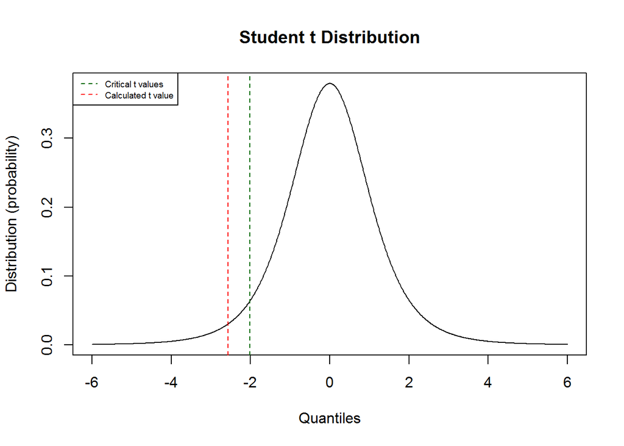

```r
# create a plot showing the outcome
xq <- seq(-6, 6, by = 0.01)  # the 'quantiles' (x values)
xp <- dt(x = xq, df = degf)  # the distribution (y values)

plot(x = xq, y = xp, type = 'l',
     xlab = 'Quantiles', ylab = 'Distribution (probability)')
title(main = 'Student t Distribution')

# plots the critical t value based on degrees of freedom (df = sample size - 1)
abline(v = tcalc, lty = 2, col = 'red')

# plots the calculate t value
abline(v = tcrit, lty = 2, col = 'darkgreen')

# add a legend
legend("topleft", legend=c("Critical t values", "Calculated t value"),
       col=c("darkgreen", "red"), lty = 2, cex=0.6)
```

Means plot

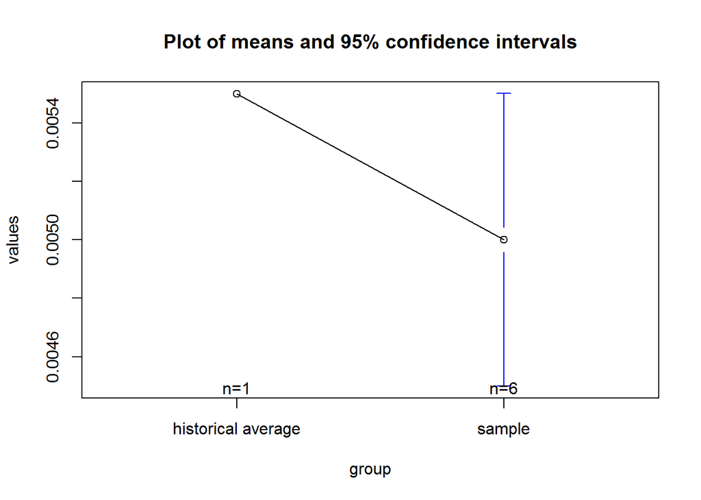

```r
library(gplots)
# Plot the mean of teeth length by dose groups
plotmeans(values ~ group, p = 0.95, data = df_wear, main = "Plot of means and 95% confidence intervals")
```